# Boruta Feature Selection and Neural Networks for Detecting Adulteration in Ground Coffee: Spectral Preprocessing by Multiplicative Scatter Correction, Savitzky-Golay, and First Derivative (MSC+SG+1st Der.)

Author

Derick Malavi

## Introduction

Coffee adulteration, such as blending premium Arabica with lower-cost Robusta, undermines quality and authenticity, posing significant challenges for consumers, producers, and regulators. High-dimensional spectroscopic data provides valuable insights for detecting such fraud, but the sheer number of variables requires effective feature selection techniques to isolate the most relevant wavelengths.

This study leverages the Boruta algorithm, a robust feature selection method that identifies all relevant variables by iteratively comparing the importance of original features with randomized counterparts using a Random Forest framework. Unlike traditional methods, Boruta not only ensures the inclusion of critical spectral features but also prevents the selection of irrelevant or redundant variables, which is essential for improving model interpretability and accuracy.

```r
# Load libraries
warning = FALSE
  suppressWarnings(suppressMessages({
  library(caret)
  library(GA)
  library(Boruta)
  library(ggplot2)
  library(dplyr)
  library(readxl)
  library(readr)
  library(pls)
  library(ggthemes)
  library(janitor)
  library(class)
  library(MLmetrics)
  library(MLeval)
  library(themis)
  library(ROSE)
  library(parallel)
  library(doParallel)
  library(foreach)
  library(pheatmap)
  library(mdatools)
  library(nnet)
  library(DMwR)
  library(e1071)
  library(knitr)
  library(pROC)
  library(gridExtra)
  library(FactoMineR)
  library(doSNOW)
  library(MASS)
  library(factoextra)
  library(kernlab)}))
```

## Prepare Data

```r
# Load data: msc_sg_1d spectra

hsi_msc_sg_1d <- read.csv("coffee_ground_msc_sg_1d.csv")

# Ensure we have the same number of dimensions and the range of our columns/covariates
dim(hsi_msc_sg_1d)
```

```
[1] 1469  229
```

```r
# Check a few column names
col_check <- colnames(hsi_msc_sg_1d[,c(1:6)])
col_check
```

```
[1] "sample_id"     "binary_class"  "three_class"   "adult_percent"
[5] "cal_val"       "X935.609985"
```

```r
# The spectral values start from column # 6-------> 229

# Convert the class to a factor
hsi_msc_sg_1d$binary_class <- as.factor(hsi_msc_sg_1d$binary_class)
```

## Get the X and y variables

```r
X <- hsi_msc_sg_1d[,c(6:229)]
y <- hsi_msc_sg_1d[,2]

class(y) #Ensure y (target variable) is a factor for classification
```

```
[1] "factor"
```

## Visualize X

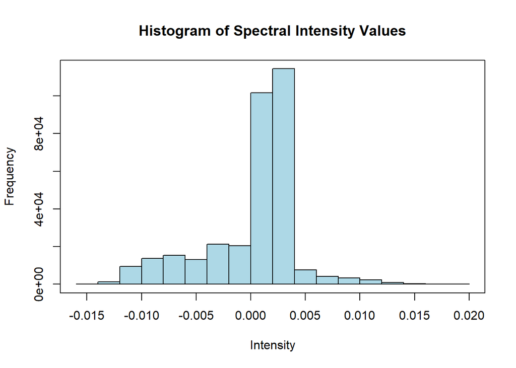

```r
hist(as.matrix(X), col = 'lightblue',
     main = 'Histogram of Spectral Intensity Values', xlab = 'Intensity'); box()
```